```python
# You will likely need more imports!
import numpy as np
import torch
import torch.nn as nn
import matplotlib as mpl
from torch.utils.data import DataLoader
from torchvision import datasets
from torchvision.transforms import ToTensor
import matplotlib.pyplot as plt
```

# Problem 1

Note that the class labels have already been encoded for you. Label "1" corresponds to stars; "2" to galaxies; and "3" to quasars.

```python
data = np.load('pset3-1.npz')
features = data['features']
labels = data['labels']
```

```python
# Normalise the features here
def normalise_features(data):
    mean = np.mean(data)
    std_dev = np.std(data)
    normalised_data = (data - mean) / std_dev
    return normalised_data

norm_features = normalise_features(features)
```

Now, we will convert our numpy arrays into Pytorch tensors.

Then, split into a training and test set (using a 80/20 split).

Finally, we will convert our training and test sets into Pytorch Datasets. We will use these to build custom DataLoaders to load our data in smaller batches.

```python
from sklearn.model_selection import train_test_split
from torch.utils.data import TensorDataset, DataLoader

# Numpy array error so convert to arrays briefly
norm_features = np.array(norm_features)
labels = np.array(labels)

X_train, X_test, class_train, class_test = train_test_split(norm_features, labels, test_size=0.2, train_size=0.8, random_state=12, shuffle=True, stratify=None)

# Convert the split data back to PyTorch tensors
X_train = torch.from_numpy(X_train).to(torch.float64)
X_test = torch.from_numpy(X_test).to(torch.float64)
class_train = torch.from_numpy(class_train).to(torch.float64)
class_test = torch.from_numpy(class_test).to(torch.float64)

training_dataset = TensorDataset(X_train, class_train)
test_dataset = TensorDataset(X_test, class_test)

BATCHSIZE = 128
BATCHSIZE_TEST = 256 #len(X_test)??
# Ask in OH why batch is not iterating in print, is it print issue or is my model actually not ushing it

train_dataloader = DataLoader(training_dataset, batch_size=BATCHSIZE, shuffle=True)
test_dataloader  = DataLoader(test_dataset, batch_size=BATCHSIZE_TEST, shuffle=True)
```

from class norm_features = torch.from_numpy(features).to(torch.float32) #float64 removed labels = torch.from_numpy(labels -1) to(torch.long)

1a: Here we normalise using function and separate into train test sets. Our x_train is our input data (features, SDDS spectra) that we use for training. X_test is our untouched input data for our test at end. Class_train is our labels (tells us class: galaxy, stars and quasars). Class_test will be our labels we use to test at end.

- Ask about array/float in OH

Fill in the following variables.

What is the dimensionality of our dataset? This will be our "input size". Note that this is NOT equal to the number of spectra in our dataset. It is equal to the number of features.

The latent size is the size of your latent space. I suggest ~5, but feel free to play around with this number!

The hidden size is the number of neurons in the layers between our latent layer and the input/output. I suggest ~100, but feel free to play around with this number!

```python
data_size      = np.shape(norm_features) # Fill
print(data_size)
INPUT_SIZE = np.shape(norm_features)[1]
print(INPUT_SIZE)
LATENT_SIZE     = 5 # Change from 5 to 3 outputs as of lecture
HIDDEN_SIZE     = 100
```

```
(3931, 1000)
1000
```

The dimension of our input is 1000 (features)

Now, we will make our autoencodoer structure.

Note that this needs to be edited where you see ">>> <<<"

```python
# Note that this code is largely from https://github.com/LSSTC-DSFP/LSSTC-DSFP-Sessions/tree/main/Sessions/Session14
# First, we will inherit from pytorch Module class; https://pytorch.org/docs/stable/generated/torch.nn.Module.html

class Encoder(nn.Module):
    def __init__(self, seed=42): # Changed to take inputs as of class
        """
        seed: int, random seed for reproducibility
        """
        super(Encoder, self).__init__()
        self.seed = torch.manual_seed(seed)

        # here we are initialising the linear layers. This registeres the layer parameters (W,b) as parameters of the Module
        self.fc1 = nn.Linear(INPUT_SIZE,HIDDEN_SIZE)
        self.fc2 = nn.Linear(HIDDEN_SIZE,LATENT_SIZE)

        # We will initialise weights following a multivariate Gaussian
        nn.init.normal_(self.fc1.weight, mean=0, std=0.01)
        nn.init.normal_(self.fc1.bias, mean=0, std=0.01)
        nn.init.normal_(self.fc2.weight, mean=0, std=0.01)
        nn.init.normal_(self.fc2.bias, mean=0, std=0.01)

    # this defines a forward pass of the network (="applying" the network to some input data)
    def forward(self, x):
        x      = torch.nn.LeakyReLU()(self.fc1(x)) # Hidden with activation
        z      = self.fc2(x)
        return z

class Decoder(nn.Module):
    def __init__(self, seed=42): # Changed from no inputs from class
        """
        seed: int, random seed for reproducibility
        """
        super(Decoder, self).__init__()
        self.seed = torch.manual_seed(seed)
        # Using the encoder, how will you initialize two layers?
        self.fc1 = nn.Linear(LATENT_SIZE,HIDDEN_SIZE)
        self.fc2 = nn.Linear(HIDDEN_SIZE,INPUT_SIZE)

        # Using the endoer, how will you initialize the weights and biases?
        # Initialise weights and biases using same as encoder?
        nn.init.normal_(self.fc1.weight, mean=0, std=0.01)
        nn.init.normal_(self.fc1.bias, mean=0, std=0.01)
        nn.init.normal_(self.fc2.weight, mean=0, std=0.01)
        nn.init.normal_(self.fc2.bias, mean=0, std=0.01)


    def forward(self, z):
        # Using the encoder, how will you define the forward pass?
        # I recommend the same activation function!
        x = torch.nn.LeakyReLU()(self.fc1(z))  # Apply LeakyReLU to the first layer's output
        x = self.fc2(x)          # Reconstruct the input

        return x

class Autoencoder(nn.Module):
    def __init__(self):
        super(Autoencoder, self).__init__()
        # here we are creating instances of the Encoder and Decoder class
        self.encoder = Encoder()
        self.decoder = Decoder()

    def forward(self, x):
        z = self.encoder(x)
        x = self.decoder(z)
        return x
```

Encoder take sinput data and compresses to hidden size and then to latent size.  
For our decoder we want to take the output (latent size) from the encoder and reconstruct original input data.  
Initialise two layers with opposite layers to encoder so we can reconstruct.  
Initialise weights and biases the same way as encoder (unsure)  
Define forward as reverse of encoder. Pass z through first layer and apply Leaky ReLU. Pass output of first layer through second layer.

Now, we will create an instance of our autoencoder class to be trained.

```python
# This creates an instance of the Autoencoder class
AE = Autoencoder()
```

```python
# Check the training DataLoader
for batch, (X, y) in enumerate(train_dataloader):
    print(f"Batch {batch + 1}: X.shape = {X.shape}, y.shape = {y.shape}")
    if batch == 0:
        break  # Only check the first batch
```

```
Batch 1: X.shape = torch.Size([128, 1000]), y.shape = torch.Size([128])
```

```python
print(f"Training dataset size: {len(training_dataset)}")
print(f"Test dataset size: {len(test_dataset)}")
```

```
Training dataset size: 3144
Test dataset size: 787
```

```python
print(f"Batch size (training): {BATCHSIZE}")
print(f"Batch size (testing): {BATCHSIZE_TEST}")
```

```
Batch size (training): 128
Batch size (testing): 256
```

```python
for batch, (X, y) in enumerate(train_dataloader):
    print(f"Processing batch {batch + 1}: X.shape = {X.shape}, y.shape = {y.shape}")
    # Your training code here
```

```
Processing batch 1: X.shape = torch.Size([128, 1000]), y.shape = torch.Size([128])
Processing batch 2: X.shape = torch.Size([128, 1000]), y.shape = torch.Size([128])
Processing batch 3: X.shape = torch.Size([128, 1000]), y.shape = torch.Size([128])
Processing batch 4: X.shape = torch.Size([128, 1000]), y.shape = torch.Size([128])
Processing batch 5: X.shape = torch.Size([128, 1000]), y.shape = torch.Size([128])
Processing batch 6: X.shape = torch.Size([128, 1000]), y.shape = torch.Size([128])
Processing batch 7: X.shape = torch.Size([128, 1000]), y.shape = torch.Size([128])
Processing batch 8: X.shape = torch.Size([128, 1000]), y.shape = torch.Size([128])
Processing batch 9: X.shape = torch.Size([128, 1000]), y.shape = torch.Size([128])
Processing batch 10: X.shape = torch.Size([128, 1000]), y.shape = torch.Size([128])
Processing batch 11: X.shape = torch.Size([128, 1000]), y.shape = torch.Size([128])
Processing batch 12: X.shape = torch.Size([128, 1000]), y.shape = torch.Size([128])
Processing batch 13: X.shape = torch.Size([128, 1000]), y.shape = torch.Size([128])
Processing batch 14: X.shape = torch.Size([128, 1000]), y.shape = torch.Size([128])
Processing batch 15: X.shape = torch.Size([128, 1000]), y.shape = torch.Size([128])
Processing batch 16: X.shape = torch.Size([128, 1000]), y.shape = torch.Size([128])
Processing batch 17: X.shape = torch.Size([128, 1000]), y.shape = torch.Size([128])
Processing batch 18: X.shape = torch.Size([128, 1000]), y.shape = torch.Size([128])
Processing batch 19: X.shape = torch.Size([128, 1000]), y.shape = torch.Size([128])
Processing batch 20: X.shape = torch.Size([128, 1000]), y.shape = torch.Size([128])
Processing batch 21: X.shape = torch.Size([128, 1000]), y.shape = torch.Size([128])
Processing batch 22: X.shape = torch.Size([128, 1000]), y.shape = torch.Size([128])
Processing batch 23: X.shape = torch.Size([128, 1000]), y.shape = torch.Size([128])
Processing batch 24: X.shape = torch.Size([128, 1000]), y.shape = torch.Size([128])
Processing batch 25: X.shape = torch.Size([72, 1000]), y.shape = torch.Size([72])
```

We will now define a training and test loop to train out model. The "test" loop will keep track of the test set for each epoch, but it will *not* update the model weights.

```python
# the training loop takes a function that loads the data batch by batch, a model to train, a loss function to train the model on and an optimizer
def train_loop(dataloader, model, loss_fn, optimizer):
    size = len(dataloader.dataset)
    losses = []
    # iterate over the dataset
    for batch, (X, y) in enumerate(dataloader):
        # Compute prediction of the model
        X = X.float() # Convert to avoid error
        pred = model(X)
        # Compute the loss function
        loss = loss_fn(pred,X)

        # Backpropagation; this is where we take the gradient and update the network parameters
        optimizer.zero_grad()
        loss.backward()
        optimizer.step()

        # here we keep track of the loss
        if batch % 100 == 0: # Allow for batches not 1st to print and track
            loss, current = loss.item(), batch * len(X)
            losses.append(loss)
            #print(f"loss: {loss:>7f}  [{current:>5d}/{size:>5d}]")

    return losses

# the test loop is similar to the training loop, only that we don't take any gradients/don't update the network parameters, but only evaluate
def test_loop(dataloader, model, loss_fn):
    size = len(dataloader.dataset)
    num_batches = len(dataloader)
    test_loss =  0

    model.eval() # From class
    with torch.no_grad():
        for (X, y) in dataloader:
            X = X.float() # Fix error
            pred = model(X)
            #test_loss += loss_fn(pred, y).item()
            test_loss += loss_fn(pred, X).item() # Switched from class

    test_loss /= num_batches
    #print(f" Avg loss: {test_loss:>8f} \n")

    return test_loss
```

```python
EPOCHS = 300
LEARNING_RATE = 1e-3 #To be filled. I recommend trying 1e-3, 1e-4, and 1e-5

# MeanSquaredError (L2) Loss
loss_fn         = nn.MSELoss() # Given in Pset
# Adam Optimizer
optimizer       = torch.optim.Adam(AE.parameters(), lr=LEARNING_RATE)

train_loss = []
test_loss  = []
for t in range(EPOCHS):
    #print(f"Epoch {t+1}\n-------------------------------")
    train_loss.append(train_loop(train_dataloader, AE, loss_fn, optimizer))
    test_loss.append(test_loop(test_dataloader, AE, loss_fn))
print("Done!")
```

```
Done!
```

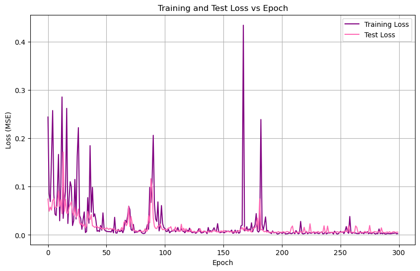

```python
import matplotlib.pyplot as plt

# Plot the training and test loss curves
plt.figure(figsize=(10, 6))
plt.plot(train_loss, label="Training Loss", color="purple")
plt.plot(test_loss, label="Test Loss", color="hotpink")

# Add labels, title, and legend
plt.xlabel("Epoch")
plt.ylabel("Loss (MSE)")
plt.title("Training and Test Loss vs Epoch")
plt.legend()
plt.grid(True)

# Show the plot
plt.show()
```

Here we see that loss reduces as we continue but there are some spikes, it would look smoother if we averaged loss.

To repeat I have to recall AutoEncoder to ensure I do not continue training while testing different learning rates and epochs

```
Done!
```

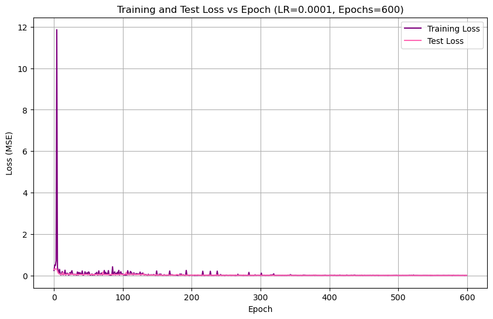

```
Done!
```

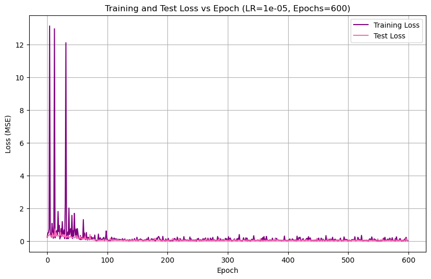

```python
# Define the learning rates and epochs to try
learning_rates = [1e-4, 1e-5]
epochs_list = [600]

# Loop over different learning rates and epochs
for lr in learning_rates:
    AE = Autoencoder()
    loss_fn = nn.MSELoss()
    optimizer = torch.optim.Adam(AE.parameters(), lr)
    for epochs in epochs_list:
        #print(f"\nTraining with learning rate = {lr} and epochs = {epochs}")

        # Clear the loss lists
        train_loss = []
        test_loss = []

        # Run the training loop
        for t in range(epochs):
            #print(f"Epoch {t+1}\n-------------------------------")
            train_loss.append(train_loop(train_dataloader, AE, loss_fn, optimizer))
            test_loss.append(test_loop(test_dataloader, AE, loss_fn))
        print("Done!")

        # Plot the loss curves for this run
        plt.figure(figsize=(10, 6))
        plt.plot(train_loss, label="Training Loss", color="purple")
        plt.plot(test_loss, label="Test Loss", color="hotpink")
        plt.xlabel("Epoch")
        plt.ylabel("Loss (MSE)")
        plt.title(f"Training and Test Loss vs Epoch (LR={lr}, Epochs={epochs})")
        plt.legend()
        plt.grid(True)
        plt.show()
```

d) Plot 16 random spectra:

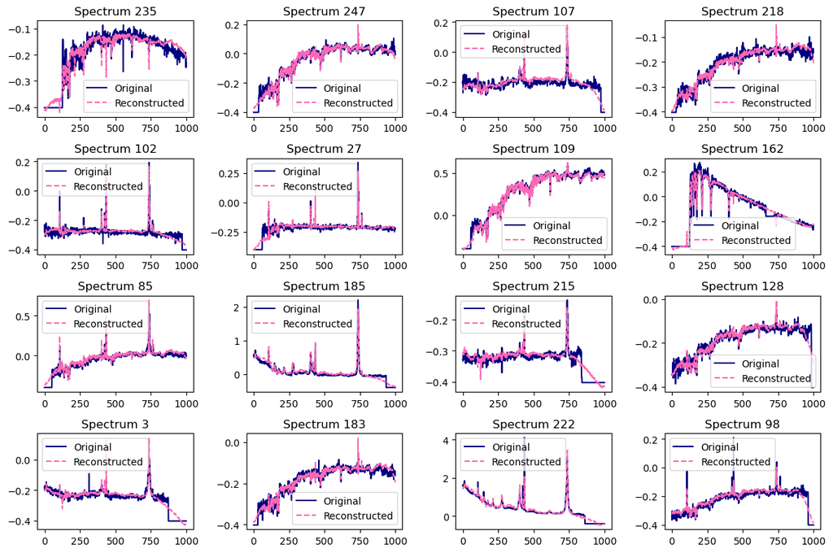

```python
AE.eval()

# Get a batch of test data
with torch.no_grad():
    test_batch = next(iter(test_dataloader))  # Get one batch
    X_test = test_batch[0].float()  # Input spectra
    X_reconstructed = AE(X_test)  # Reconstructed spectra from AE

# Detach the tensors for plotting
X_test_np = X_test.detach().cpu().numpy()
X_reconstructed_np = X_reconstructed.detach().cpu().numpy()

# Random 16
num_samples = 16
random_indices = np.random.choice(len(X_test_np), num_samples, replace=False)

# Plot the original and reconstructed spectra
plt.figure(figsize=(12, 8))
for i, idx in enumerate(random_indices):
    plt.subplot(4, 4, i + 1)
    plt.plot(X_test_np[idx], label="Original", color="navy")
    plt.plot(X_reconstructed_np[idx], label="Reconstructed", color="hotpink", linestyle="--")
    plt.legend()
    plt.title(f"Spectrum {idx + 1}")
plt.tight_layout()
plt.show()
```

Here we see that the model is a good fit for most of the orignal spectra but outliers and end points do not fit as well.

e) Plot batch in latent space

```
Reducing dimensionality using t-SNE...
```

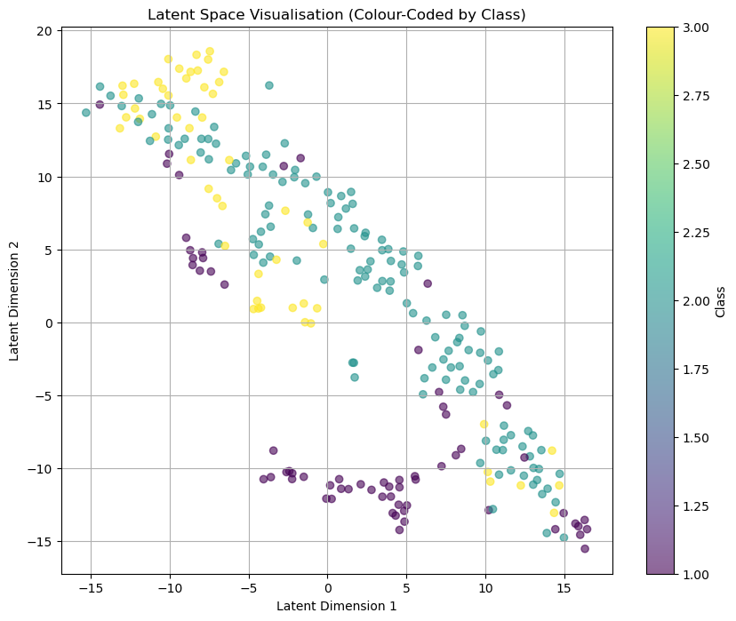

```python
from sklearn.manifold import TSNE

# Set to evaluation mode
AE.eval()

# Get a batch of test data
with torch.no_grad():
    test_batch = next(iter(test_dataloader))  # Get one batch of test data
    X_test = test_batch[0].float()  # convert spectra to float32
    y_test = test_batch[1]  # Our labels

    # Encode the test set into the latent space
    z = AE.encoder(X_test)

# Detach t and convert to numpy
z_np = z.detach().cpu().numpy()  # Shape batch_size, latent_size
y_test_np = y_test.detach().cpu().numpy()

# If latent_size is above 2 using t-SNE to reduce dimensionality
if z_np.shape[1] > 2:
    print("Reducing dimensionality using t-SNE...")
    tsne = TSNE(n_components=2, random_state=42)
    z_np = tsne.fit_transform(z_np)  # To 2D so plot

# latent space plot
plt.figure(figsize=(10, 8))
scatter = plt.scatter(z_np[:, 0], z_np[:, 1], c=y_test_np, cmap="viridis", alpha=0.6)
plt.colorbar(scatter, label="Class")
plt.xlabel("Latent Dimension 1")
plt.ylabel("Latent Dimension 2")
plt.title("Latent Space Visualisation (Colour-Coded by Class)")
plt.grid(True)
plt.show()
```

Here we can see some evidence of clustering but it is not very clear so this suggests it is not clustering well.

# Problem 2

- With k=3:

```python
# AE = Autoencoder()
AE.eval()

import torch
from sklearn.cluster import KMeans

device = torch.device("cuda" if torch.cuda.is_available() else "cpu")
AE.to(device)  # Move the model to the selected device


encoded_list = []
with torch.no_grad():
    for batch, _ in test_dataloader:
        batch = batch.float().to(device)
        encoded_list.append(AE.encoder(batch).cpu())
z = torch.cat(encoded_list)  # Combine batches

# Convert latent space representations to numpy
z_np = z.detach().cpu().numpy()
y_test_np = y_test.detach().cpu().numpy()

# If latent space >2, reduce to 2D using t-SNE
if z_np.shape[1] > 2:
    print("Reducing dimensionality using t-SNE...")
    from sklearn.manifold import TSNE
    tsne = TSNE(n_components=2, random_state=42)
    z_np = tsne.fit_transform(z_np)
```

```
Reducing dimensionality using t-SNE...
```

```python
import joblib
joblib.Parallel(n_jobs=1)


# Apply K-means clustering with k=3
kmeans = KMeans(n_clusters=3, random_state=42, n_init=10)
clusters = kmeans.fit_predict(z_np)  # Cluster assignments

# Plot the clusters
plt.figure(figsize=(10, 8))
scatter = plt.scatter(z_np[:, 0], z_np[:, 1], c=clusters, cmap="tab10", alpha=0.6)

# Overlay true labels with different marker shapes
marker_dict = {0: 'o', 1: 's', 2: 'D'}  # Example mapping of true classes
for i, label in enumerate(y_test_np):
    plt.scatter(z_np[i, 0], z_np[i, 1], color='k', marker=marker_dict.get(label, 'x'), s=20)

# Plot cluster centroids
plt.scatter(kmeans.cluster_centers_[:, 0], kmeans.cluster_centers_[:, 1], marker='X', c='red', s=200, label="Centroids")

plt.colorbar(scatter, label="Cluster")
plt.xlabel("Latent Dimension 1")
plt.ylabel("Latent Dimension 2")
plt.title("K-Means Clustering (k=3) on Encoded Spectra")
plt.legend()
plt.show()
```

I tried to debug this but I kept crashing my whole notebook everytime. I will move onto a fresh one for question 2.

```python
def make_ellipses(gmm, ax, my_var1 = 0, my_var2 = 1):
    """
    Primarily stolen from: https://scikit-learn.org/stable/auto_examples/mixture/plot_gmm_covariances.html
    gmm: GaussianMixture object from sklearn
    ax: Matplotlib axis, indication of where to plot the contour
    my_var1: int, x-axis in the latent space where you are plotting
    my_var2: int, y-axis in the latent space where you are plotting
    """
    for n in np.arange(len(gmm.covariances_)):
        covariances = gmm.covariances_[n][[[my_var1,my_var1],[my_var1, my_var2]],[[my_var1,my_var2], [my_var2,my_var2]]]
        v, w = np.linalg.eigh(covariances) #Returns the eigenvalues / vectors of our covariance matrix
        u = w[0] / np.linalg.norm(w[0])
        angle = np.arctan2(u[1], u[0])
        angle = 180 * angle / np.pi  # convert to degrees
        v = 2.0 * np.sqrt(2.0) * np.sqrt(v)
        ell = mpl.patches.Ellipse(
            gmm.means_[n, [my_var1, my_var2]], v[0], v[1], angle=180 + angle, edgecolor='k', lw=1, facecolor='none'
        )
        ell.set_clip_box(ax.bbox)
        ell.set_alpha(0.5)
        ax.add_artist(ell)
```